# NHIS 2021: Education, Health, and Well-Being

Group 3

2025-11-22

# Introduction

The National Health Interview Survey (NHIS) is a large, nationally representative survey of the U.S. population. In this project, we examine how demographic characteristics, body measurements, general health, and life satisfaction relate to one another. Our analysis uses the 2021 NHIS Sample Adult File and focuses on age (AGEP_A), sex (SEX_A), education (EDUCP_A), height (HEIGHTTC_A), weight (WEIGHTLBTC_A), general health (PHSTAT_A), and life satisfaction (LSATIS4R_A).

# Methods

We used the cleaned dataset created earlier in our project and saved as `data/nhis_clean.csv`. After importing the dataset, we converted several variables to factors with meaningful labels and produced descriptive statistics, univariate plots, bivariate comparisons, and multivariate visualizations. Height–weight trends and correlations among age, height, and weight were examined using both ggplot2 and psych’s `pairs.panels()` function.

```r
nhis <- readr::read_csv("data/nhis_clean.csv")

nhis <- nhis %>%
  mutate(
    SEX_A = factor(SEX_A, levels = c(1, 2),
                   labels = c("Male", "Female")),
    EDUCP_A = factor(EDUCP_A, levels = c(1, 2, 3, 4),
                     labels = c("Less than HS",
                                "HS graduate",
                                "Some college",
                                "College graduate+")),
    PHSTAT_A = factor(PHSTAT_A, levels = c(1, 2, 3, 4, 5),
                      labels = c("Excellent", "Very good", "Good", "Fair", "Poor")),
    LSATIS4R_A = factor(LSATIS4R_A, levels = c(1, 2, 3, 4),
                        labels = c("Very satisfied", "Satisfied", "Dissatisfied",
                                   "Very dissatisfied"))
  )

glimpse(nhis)
```

```
## Rows: 26,037
## Columns: 9
## $ ...1         <dbl> 1, 2, 3, 4, 8, 10, 11, 12, 15, 16, 19, 20, 21, 22, 23, 24…
## $ AGEP_A       <dbl> 50, 53, 56, 57, 41, 71, 69, 44, 69, 59, 41, 82, 74, 67, 7…
## $ WEIGHTLBTC_A <dbl> 199, 205, 160, 190, 206, 127, 100, 208, 165, 225, 150, 28…
## $ HEIGHTTC_A   <dbl> 69, 75, 67, 63, 72, 63, 63, 69, 71, 70, 66, 72, 66, 66, 6…
## $ SEX_A        <fct> Male, Male, Male, Female, Male, Female, Female, Male, Mal…
## $ HISPALLP_A   <dbl> 2, 3, 2, 2, 3, 2, 2, 2, 2, 2, 2, 2, 2, 2, 2, 2, 2, 3, 3, …
## $ EDUCP_A      <fct> NA, NA, NA, NA, NA, NA, NA, NA, NA, NA, NA, NA, NA, NA, N…
## $ PHSTAT_A     <fct> Very good, Very good, Very good, Fair, Excellent, Excelle…
## $ LSATIS4R_A   <fct> Satisfied, Very satisfied, Dissatisfied, Satisfied, Very …
```

# Results

## Descriptive statistics

```r
nhis %>%
  select(AGEP_A, HEIGHTTC_A, WEIGHTLBTC_A) %>%
  summary()
```

```
##      AGEP_A        HEIGHTTC_A    WEIGHTLBTC_A
##  Min.   :18.00   Min.   :59.0   Min.   :100.0
##  1st Qu.:37.00   1st Qu.:64.0   1st Qu.:147.0
##  Median :54.00   Median :66.0   Median :173.0
##  Mean   :52.57   Mean   :66.7   Mean   :176.8
##  3rd Qu.:67.00   3rd Qu.:70.0   3rd Qu.:200.0
##  Max.   :85.00   Max.   :76.0   Max.   :299.0
```

### Age distribution

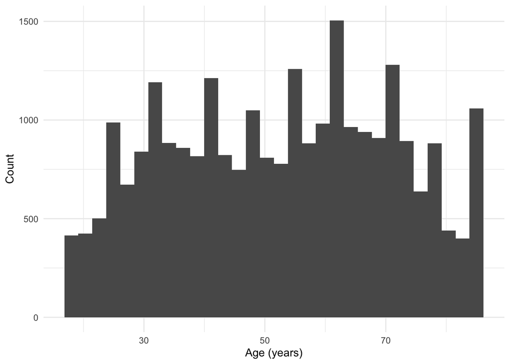

Figure 1. Distribution of age in the sample.

```r
ggplot(nhis, aes(x = AGEP_A)) +
  geom_histogram(bins = 30) +
  labs(x = "Age (years)", y = "Count")
```

**Interpretation:**  
The sample contains adults across a wide age range, with a concentration in middle-aged groups.